# 2020-03-30 Bio-Group Data Training Session

Zach

2020-03-30

# March 30, 2020

Hello, and welcome to a summary the first training session for bio-group technical development! This is an Rmarkdown document that will walk you through what we did in the first session on March 30, 2020.

With the myriad statistics of the novel coronavirus pervading most media outlets, we opted to examine the data ourselves to obtain a clearer understanding of the spread of the disease. We opted to use the dataset maintained bythe Johns Hopkins University Center for Systems Science and Engineering (JHU CSSE), for two main reasons:

```
1) They maintain a most excellent data dashboard located here:
(https://www.arcgis.com/apps/opsdashboard/index.html#/bda7594740fd40299423467b48e9ecf6)
Of particular interest to us is the spatial location data, meaning that we too
can generate our own maps from these data.  Thanks to Kelsey for the original
share!

2) The entire dataset is conveniently located on github
(https://github.com/CSSEGISandData/COVID-19), updated daily, and is entirely
contained within comma-separated-values files (.csv files).  Many modern
programming languages,including R and Python, have libraries or packages that
interface well with .csv files, making it a breeze to ingest, manipulate, and
analyze the data within!
```

In the code below, we will walk through the initial setup of this project, which includes dowloading, cleaning, and organizing the data, and we will finish by generating a plot of the daily mortality rate in the U.S. as well as the total to-date U.S. mortality count. This document is in a format known as “R Markdown”, which allows us to easily run each code chunk one at a time. The code is organized so that we may easily adapt and expand upon it to answer other questions of interest, which so far have includued adding country population counts to the dataset and generating animated heatmaps of infections/deaths/recoveries over time.  
Together, hopefully we will create some meaning from this unique situation and grow our knowledge and skillsets to better ourselves and our communities!

================================================================================

## Libraries

At the top of any script we write, first we include all the libraries used in this analysis. These “libraries” are packages of code that we import to our script so we may use some of their handy features. For example, the “xml2” library allows us to download a webpage and extract all of the text from it in just a few simple lines of code! A few commonly used libraries include data.table, dplyr, and magrittr, all of which we will go into later.

```r
library(magrittr)
library(xml2)
library(lubridate)
library(data.table)
library(dplyr)
library(ggplot2)
```

## Set paths

This line is purely procedural. Here we tell R in a platform-agnostic way where to put on your computer the downloaded csv data as well as the R scripts. In other words, R makes a guess at where your home directory is, regardless of whether you are using Windows, MacOS, or Linux.

```r
git.path <- Sys.getenv('HOME')  # Where the base COVID19-Data-Exploration folder lives.
```

## Fetching the CSV data from Github

```r
# Pull in list of daily data.
xml.path <- 'https://github.com/CSSEGISandData/COVID-19/tree/master/csse_covid_19_data/csse_covid_19_daily_reports'
report.file <- download_html(xml.path)
html.read <- read_html(report.file)
csv.list <- xml_text(html.read) %>% strsplit(split='\\n') %>% unlist
```

```r
parse_dates.fn <- function(csv.list) {
    # Parse html for the csv names
    dates.list <- lapply(csv.list, function(x) {
    if (grepl(pattern='.csv', x, fixed=TRUE)) {
        regex <- regexpr('\\d{2}-\\d{2}-\\d{4}.csv', x)
        return(substr(x, start=regex[[1]], stop=regex[[1]]+attr(regex, 'match.length')))
        }
    })

    return(dates.list)
}

dates.list <- parse_dates.fn(csv.list)
dates.list[sapply(dates.list, is.null)] <- NULL  # Drop null values in list
```

```r
# Fetch raw csv data
raw.path <- 'https://raw.githubusercontent.com/CSSEGISandData/COVID-19/master/csse_covid_19_data/csse_covid_19_daily_reports/'
suppress <- lapply(dates.list, function(x, raw.path) {
    download.file(paste0(raw.path, x), paste0(git.path,'/Code/COVID19-Data-Exploration/data/',x))
}, raw.path)
```

## Data Sanitization – Making our Data Tidy

Now that we have our data downloaded, we are ready to do some analysis, right?  
Yes, but only if our data are in the right format. In R, making one’s data “tidy” doesn’t just mean it is clean and neat in the general sense of those words; rather, it means formatting one’s data in a way that makes it easy to split it up into small chunks, apply a set of operations to each chunk, and then recombine the chunks back into a new dataset. This split-apply-combine approach is a common motif in data science and, once you get the hang of it, is a quite intuitive and useful way to handle your data!

```r
# trim whitespace and any trailing digits
trim <- function(x) return(tstrsplit(x, "\\s|[A-Z]", keep=1) %>%unlist)
```

```r
data.dt <- lapply(dates.list, function(x) {  # Split

    # -- Apply -- #
    # Fix column names and standardize date formats
    tmp.dt <- fread(paste0(git.path,'/Code/COVID19-Data-Exploration/data/',x)) %>% data.table
    colnames(tmp.dt) <- colnames(tmp.dt) %>% gsub('[ \\/]', '_', .)  # sub spaces and slashes for underscore
    # Fix date formatting for first 10 days
    tryCatch({
        tmp.dt$Last_Update <- tmp.dt$Last_Update %>%
            trim %>%
            parse_date_time(orders=c('%m/%d/%y','%m/%d/%Y','%Y-%m-%d'))
        return(tmp.dt)},
        warning = function(w) {
            message(paste('Warning!  Check file:', x))
        },
        error = function(e) {
            message(paste('Error!  Check file', x))
        }
    )
    # -- End of Apply -- #

}) %>% rbindlist(fill=TRUE) # Combine
```

## Filtering the Dataset

```r
data.dt[data.dt$Deaths%>%is.na, 'Deaths'] <- 0
us_deaths.dt <- data.dt[data.dt$Country_Region=='US',] %>% group_by(Last_Update) %>%
    summarize(Daily_Deaths=max(Deaths)) %>% data.table
us_deaths.dt$Cumulative_Deaths <- cumsum(us_deaths.dt$Daily_Deaths)
print(paste('Total U.S. Deaths:', sum(us_deaths.dt$Daily_Deaths)))
```

```
## [1] "Total U.S. Deaths: 13003"
```

## Our First Plot

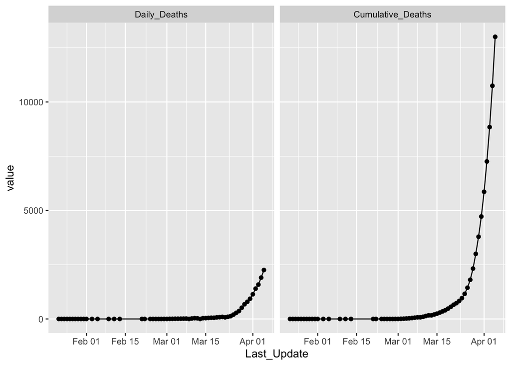

```r
melted.dt <- melt(us_deaths.dt, id.vars='Last_Update', variable.name = 'Deaths')

ggplot(melted.dt, aes(x=Last_Update, y=value)) +
    geom_point() +
    geom_line() +
    facet_wrap('Deaths')
```